# **Preparing Data Before Further Computations**

#### First, data must be compiled from NOAA's download webpage. The automatic process is shown below. However, each year is its own file, so in order to do any computations, they must be compiled into a singular matrix.

```python
#This is how to download the data straight from the NOAA website for a string of years.
#For me, this string of years is from 1980 to 2012.
for year in years:
   url = 'https://downloads.psl.noaa.gov/Datasets/godas/pottmp.'+str(year)+'.nc'
       r = requests.get(url, allow_redirects = True)
       open('pottmp.'+str(year)+'.nc', 'wb').write(r.content)
#This is the compiling of all the separate nc files into 1 list.
WaterData = []
for year in years:
    file = 'C:/Users/tbui0/Yearly Pottmps/pottmp.'+str(year)+'.nc'
    WaterData.append(nc.Dataset(file))
```

#### All the years for monthly mean air temperature are in one file so unlike the water data, it did not require any code to automate downloading it. But we only want to look at the Januaries of Air and Ocean because the temperature vastly changes through the seasons. The Air data dates back to 1871 whereas the ocean data only dates back to 1980. Both the monthly related and annually related issues are solved by splicing the data shown below.

```python
air = air[(1980-1871)*12::12, :,:,:]
```

We then combine the Air and Ocean data into one large matrix to do calculations with

```python
CombinedData = []
for g in range(0, len(WaterData)):
    YEARLY_AIR = np.array(air[g].flatten()).tolist()
    ANNUAL_WATER = WaterData[g].variables['pottmp'][:]
    YEARLY_WATER = np.array(ANNUAL_WATER[0].flatten()).tolist()
    CombinedData.append(YEARLY_AIR + YEARLY_WATER)
CombinedData = np.array(CombinedData).T
CombinedData.shape
```

##### Another thing one must consider are Nan values. In the ocean data, since water does not cover the entire globe, there will be Nan data points (or points that are land instead of water). NOAA formats these Nans as the value $-9.9 \times 10^{36}$. We do not want this number in our calculations because the temperature of the water at that point is not $-9.9 \times 10^{36} K$, but nonexistant.

```python
#Replaces with Nan because of how GODAS data is formatted
for i in range(0, CombinedData.shape[0]):
    for j in range(0, CombinedData.shape[1]):
        if (CombinedData[i,j] < 0):
            CombinedData[i,j] = np.nan
```

# **Standardizing and Normalizing Data**

#### Typically, data is normalized and standardized before further processing. For the prupose of this particular computation, it eliminates the significance of the units the data is measured in. Whether the data was measured in Kelvin, Centigrade, Fahrenheit, etc. the resulting thermal patterns post-computation should be the same.

#### Mathematically, standardized and mean-centered data holds much more information than the raw data or raw anomalies. The raw data does not provide much other than the temperature of that spot in that point in time. The anomalies provide whether the temperature is relatively high or low for that moment in time, but not the extremity of the thermal difference. The standardized and normalized data provide a z-score which provides not only whether the temperature is higher or lower than the typical value, but the extremity of the anomaly.

```python
import warnings
with warnings.catch_warnings():
    warnings.simplefilter("ignore", category=RuntimeWarning)
    clim = np.nanmean(CombinedData, axis=1)
    sdev = np.nanstd(CombinedData, axis = 1)
clim = np.reshape(clim, (clim.size, 1))
sdev = np.reshape(sdev, (sdev.size,1))
#Calculating standardized anomalies
stnd_anom = (CombinedData - clim)/ sdev
```

# **The Big Difference**

#### Below, I have the raw data for January 1998 Ocean Temperature at Sea Level as well as the standardized anomaly equivalent. While the raw data appear monotone chromatically, the standardized anomaly illustrates prominent patterns in the variance of ocean temperatures

```python
stnd_anom = np.load('StandardizedCombined.npy')
CombinedData = np.load('JanuaryRaw.npy')
```

#### There is no significant pattern other than the water is warmer near the equator and cooler around the North and South poles. This is essentially common knowledge and do not provide any unique information on January 1998.

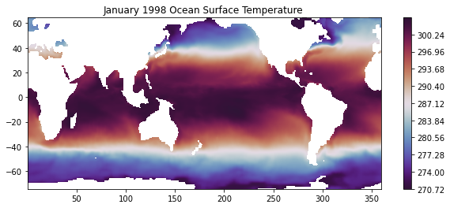

#### There is a significantly noticeable pattern in the Pacific Ocean due to El Nino. Off the west coast of MesoAmerica, the water is signficantly warmer than usual. Likewise, surrounding the relatively warmer water, we have relatively cooler water shaped like a warped $ \lambda $ and see extensions of such

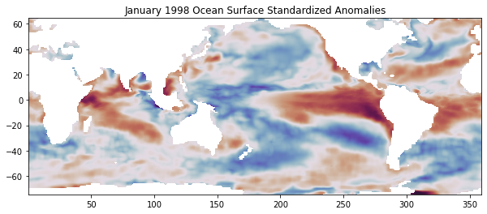

# Additional Processing

#### There is additional processing required before one can compute the Thermal EOFs. This has to do with the materialistic properties of water and air as well as the grid and geophysical space that must be considered. That will be demonstrated in the following post.